# IODS course project

Correlations between study variables: Many of the study variables correlate with each other at least modestly. Strongest positive correlations (> 0.70) are found between rad and tax (r = 0.91), indus and nox (r = 0.76), nox and age (r = 0.73), indus and tax (r = 0.72), and rm and medv (r = 0.70). Strongest negative correlations (< -0.70) are found between nox and dis (r = -0.77), indus and dis (r = -0.71), age and dis (r = -0.75), and lstat and medv (r = -0.74).

Let’s next standadize the data and see how the variables change.

```r
#Standardizing the data set
boston_scaled <- scale(Boston)

# class of the boston_scaled object
class(boston_scaled)
```

```
## [1] "matrix" "array"
```

```r
# change the object to data frame
boston_scaled <- as.data.frame(boston_scaled)

# summaries of the scaled variables
summary(boston_scaled)
```

```
##       crim                 zn               indus              chas
##  Min.   :-0.419367   Min.   :-0.48724   Min.   :-1.5563   Min.   :-0.2723
##  1st Qu.:-0.410563   1st Qu.:-0.48724   1st Qu.:-0.8668   1st Qu.:-0.2723
##  Median :-0.390280   Median :-0.48724   Median :-0.2109   Median :-0.2723
##  Mean   : 0.000000   Mean   : 0.00000   Mean   : 0.0000   Mean   : 0.0000
##  3rd Qu.: 0.007389   3rd Qu.: 0.04872   3rd Qu.: 1.0150   3rd Qu.:-0.2723
##  Max.   : 9.924110   Max.   : 3.80047   Max.   : 2.4202   Max.   : 3.6648
##       nox                rm               age               dis
##  Min.   :-1.4644   Min.   :-3.8764   Min.   :-2.3331   Min.   :-1.2658
##  1st Qu.:-0.9121   1st Qu.:-0.5681   1st Qu.:-0.8366   1st Qu.:-0.8049
##  Median :-0.1441   Median :-0.1084   Median : 0.3171   Median :-0.2790
##  Mean   : 0.0000   Mean   : 0.0000   Mean   : 0.0000   Mean   : 0.0000
##  3rd Qu.: 0.5981   3rd Qu.: 0.4823   3rd Qu.: 0.9059   3rd Qu.: 0.6617
##  Max.   : 2.7296   Max.   : 3.5515   Max.   : 1.1164   Max.   : 3.9566
##       rad               tax             ptratio            black
##  Min.   :-0.9819   Min.   :-1.3127   Min.   :-2.7047   Min.   :-3.9033
##  1st Qu.:-0.6373   1st Qu.:-0.7668   1st Qu.:-0.4876   1st Qu.: 0.2049
##  Median :-0.5225   Median :-0.4642   Median : 0.2746   Median : 0.3808
##  Mean   : 0.0000   Mean   : 0.0000   Mean   : 0.0000   Mean   : 0.0000
##  3rd Qu.: 1.6596   3rd Qu.: 1.5294   3rd Qu.: 0.8058   3rd Qu.: 0.4332
##  Max.   : 1.6596   Max.   : 1.7964   Max.   : 1.6372   Max.   : 0.4406
##      lstat              medv
##  Min.   :-1.5296   Min.   :-1.9063
##  1st Qu.:-0.7986   1st Qu.:-0.5989
##  Median :-0.1811   Median :-0.1449
##  Mean   : 0.0000   Mean   : 0.0000
##  3rd Qu.: 0.6024   3rd Qu.: 0.2683
##  Max.   : 3.5453   Max.   : 2.9865
```

```r
sd(boston_scaled$crim)
```

```
## [1] 1
```

```r
sd(boston_scaled$zn)
```

```
## [1] 1
```

Standardizing the data changed the scale of all variables so that the mean is 0 and standard deviation is 1.

Creating categorical variable of the crime rate variable and removing the continuous crim variable from the data. The new categorical crime variable has 4 categories: low, med_low, med_high and high.

```r
# create a quantile vector of crim
bins <- quantile(boston_scaled$crim)
# create a categorical variable 'crime'
crime <- cut(boston_scaled$crim, breaks = bins, include.lowest = TRUE, label=c("low", "med_low", "med_high", "high"))
# look at the table of the new factor crime
table(crime)
```

```
## crime
##      low  med_low med_high     high
##      127      126      126      127
```

```r
# remove original crim from the dataset
boston_scaled <- dplyr::select(boston_scaled, -crim)
# add the new categorical value to scaled data
boston_scaled <- data.frame(boston_scaled, crime)
```

Dividing the data to training set (80% of data) and test set (20% of data). The idea is to fit a linear discriminant analysis in the training data and than predict the classes in the test data in order to see how well the prediction works.

```r
# number of rows in the Boston dataset
n <- nrow(boston_scaled)

# choose randomly 80% of the rows
ind <- sample(n,  size = n * 0.8)

# create train set
train <- boston_scaled[ind,]

# create test set
test <- boston_scaled[-ind,]
```

Next, let’s fit a linear discriminant analysis on the train data set using categorical crime variable as the target variable.

```r
# linear discriminant analysis
lda.fit <- lda(crime ~ ., data = train)

# print the lda.fit object
lda.fit
```

```
## Call:
## lda(crime ~ ., data = train)
##
## Prior probabilities of groups:
##       low   med_low  med_high      high
## 0.2698020 0.2425743 0.2351485 0.2524752
##
## Group means:
##                  zn      indus         chas        nox          rm        age
## low       0.9286887 -0.9574077 -0.127848325 -0.8851442  0.41609636 -0.8915133
## med_low  -0.1271597 -0.2601376 -0.031282114 -0.5846432 -0.17012444 -0.3619388
## med_high -0.4050966  0.1555176  0.183545696  0.3401926  0.08374304  0.4414816
## high     -0.4872402  1.0171096 -0.002135914  1.1166359 -0.37199446  0.8252206
##                 dis        rad        tax     ptratio       black        lstat
## low       0.9288973 -0.6857985 -0.7324687 -0.42314416  0.37888227 -0.773012171
## med_low   0.3865031 -0.5459225 -0.4907925 -0.09022376  0.30775083 -0.102854710
## med_high -0.3750347 -0.4161001 -0.3063845 -0.25903504  0.07165988 -0.001239692
## high     -0.8570787  1.6382099  1.5141140  0.78087177 -0.81754821  0.847346905
##                  medv
## low       0.494994374
## med_low   0.003533699
## med_high  0.147624728
## high     -0.684407936
##
## Coefficients of linear discriminants:
##                 LD1         LD2         LD3
## zn       0.08002084  0.69883607 -0.86283605
## indus    0.01563236 -0.37572917  0.62613820
## chas    -0.11720189 -0.05775199  0.01175827
## nox      0.45975504 -0.51326451 -1.46360305
## rm      -0.12111861 -0.07391570 -0.18192486
## age      0.21417394 -0.36638717 -0.25227429
## dis     -0.06283819 -0.17465673  0.26591488
## rad      3.33658527  0.91423586  0.36178110
## tax      0.08033476  0.08028822  0.18766912
## ptratio  0.09316829  0.07089471 -0.33779536
## black   -0.10378921  0.01076796  0.11825960
## lstat    0.21724759 -0.26693518  0.50446415
## medv     0.19754394 -0.33135741 -0.03627153
##
## Proportion of trace:
##    LD1    LD2    LD3
## 0.9533 0.0340 0.0127
```

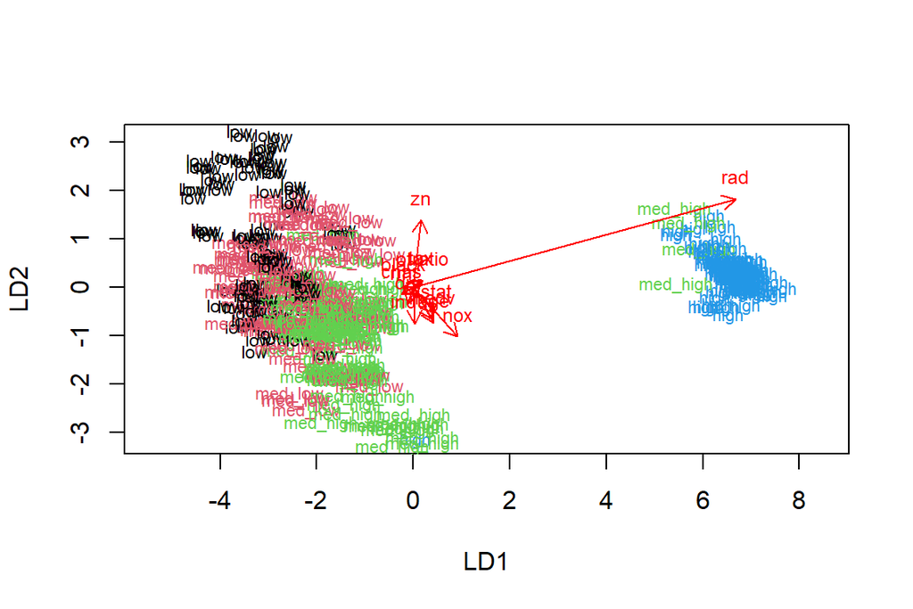

```r
# the function for lda biplot arrows
lda.arrows <- function(x, myscale = 1, arrow_heads = 0.1, color = "red", tex = 0.75, choices = c(1,2)){
  heads <- coef(x)
  arrows(x0 = 0, y0 = 0,
         x1 = myscale * heads[,choices[1]],
         y1 = myscale * heads[,choices[2]], col=color, length = arrow_heads)
  text(myscale * heads[,choices], labels = row.names(heads),
       cex = tex, col=color, pos=3)
}

# target classes as numeric
classes <- as.numeric(train$crime)

# plot the lda results
plot(lda.fit, dimen = 2, col = classes, pch = classes)
lda.arrows(lda.fit, myscale = 2)
```

From the plot it can be seen that the variable “rad” (index of accessibility to radial highways) is the most discriminative variable in the discriminant model. Other discriminative variables are nox (nitrogen oxides concentration (parts per 10 million) and zn (proportion of residential land zoned for lots over 25,000 sq.ft). Perhaps all these variables are indicative of a bigger town?

```r
# save the correct classes from test data
correct_classes <- test$crime

# remove the crime variable from test data
test <- dplyr::select(test, -crime)

# predict classes with test data
lda.pred <- predict(lda.fit, newdata = test)

# cross tabulate the results
table(correct = correct_classes, predicted = lda.pred$class)
```

```
##           predicted
## correct    low med_low med_high high
##   low       14       4        0    0
##   med_low    7      10       11    0
##   med_high   2       6       21    2
##   high       0       0        0   25
```